# Shelter Dogs

ADS Project 5 Group 10

## Introduction

Every year 7.6 million companion animals enter shelters every year. With 13,600 shelters nationwide, it is could be considered a large buisness empire. So what happens to all the dogs that enter the shelter? We decided to investigate what factors could potentially determine the likelyhood of a dog’s outcome.

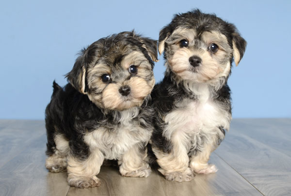

## Dataset preparation

Our data is taken from Kaggles’ Shelter competition. This data composes information from one shelter in Austin, Texas between the spam of 2013 to 2015. It includes over 30000 domistic animals. In this study, we focused particularily on dogs.

The data set originally contained 20 attributes. In particular, Breed and Color contained over 3000 unique factors. Because majority of the dogs are mixed. We wanted to provide the ability to capture a difference between purebreeds and different categories of dog. For color, wedecided to focus on the first color listed and indicate if it is a mix color breed. This is because an animal has a dominate color. After refactoring these columns, we have 36 types of dogs along with 30 different colors.

For age, we changed all animals to be calculated by days because there were multiple animals that were less than a month old.

Please reference “../lib/Data Preparation Code.R”.

- Original

```
##  [1] "Animal ID"        "Frequency"        "Count"
##  [4] "Name"             "Intake Date"      "Intake Time"
##  [7] "Found Location"   "Intake Type"      "Intake Condition"
## [10] "Animal Type"      "Sex upon Intake"  "Age upon Intake"
## [13] "Breed"            "Color"            "Outcome Date"
## [16] "Outcome Time"     "Outcome Type"     "Outcome Subtype"
## [19] "Sex upon Outcome" "Age upon Outcome"
```

- New

```
##  [1] "Animal ID"        "Frequency"        "Count"
##  [4] "Name"             "Intake Date"      "Intake Time"
##  [7] "Found Location"   "Intake Type"      "Intake Condition"
## [10] "Animal Type"      "Sex upon Intake"  "Age upon Intake"
## [13] "Breed"            "Color"            "Outcome Date"
## [16] "Outcome Time"     "Outcome Type"     "Outcome Subtype"
## [19] "Sex upon Outcome" "Age upon Outcome" "Breed_Mix"
## [22] "Breed1"           "Breed2"           "MainColor"
## [25] "Color_Mix"        "Breed_New"
```

## Outcome Type

We started to look at the frequency of the outcome. As shown below, the largest four components are adoption, transfer, return to owner, and euthanasia. Because the other components make up a small component, we set a primary forcus on the others.

[interactive chart not shown]

## Dataset vs.Outcome

### Seasonality

To start, we looked at the seasonality of the animals in the shelter. From the graph, we noticed that there seems to be some seasonality between the animals. However, when we furthered divided the animals we noticed there is a large seasonlity component for cats. This is not present for dogs. We can conclude there is very little seasonality for dogs.

[interactive chart not shown]

### Days in shelter VS. Outcome

We also anaylized how the number of days in the shelter affected the outcome of the dog. From the graph, we can note that majority of the dogs stay for less than 10 days. For dogs who return to owners, they are more quickly returned than dogs who are adopted.

[interactive chart not shown]

### Dog name VS. Outcome

We then analyzed if a dog has a name, how it will affect its outcome. As we can see, there seem to be a higher rate of being returned to owner if the dog has a name. There is also a significant increase for a dog to be transferred if it has no name. The adoption rate, however remains the same.

[interactive chart not shown]

### Sex Vs. Outcome

We then noticed that the gender of the dog is divided into four categories: Neutered Male, Spayed Female, Intact Female, and Intact Male. For the dogs being returned to the owner, we noticed there is a larger spike for a specific dog to be a neutered male. All other categories remain the same.

[interactive chart not shown]

### Dog Breeds

#### Frequency of breeds in shelter relative to their baseline frequency

Here we compare the frequency of each pure breed in the shelter relative to its baseline frequency in American homes. Positive values (red colors) indicate over-represented breeds in the shelter. These are, presumably, breeds more likely to be abandoned. Negative values (green) indicate the opposite.

[interactive chart not shown]

Keeping in mind, this only shows pure breed dogs. We can see that there are selective dogs that are more likely to end up in the pound such as Austrilian Cattle Dog. Popular dogs such a goldren retriver appears less.

#### Breed Group

A breed group is a categorization of related breeds of animal by an overseer organization, used to organize the showing of animals. In dogs, kennel clubs define the Breed Groups and decide which dog breeds are to be included in each breed group.

- Herding
- Working
- Toy
- Hound
- Terrier
- Sporting
- Non-sporting

#### Breed VS. Outcome

We then studied if the dog breed function effects the outcome of the dog. In particular, we focuesed on adoption. After recategorizing the dogs based on breed, function, and mix. We categorized the dog into 36 categories. Then we got the outcome ratio.

[interactive chart not shown]

* Non-sporting & Others only consists of one dog

We noticed that hound dog seem to have the highest rate of adoption. And pure dogs, such as non-sporting, terrier and working, had high rate of return to owners.

```r
rev(adoption_rate$Breed)
```

```
##  [1] Hound & Working         Hound & Toy
##  [3] Herding & Toy           Herding & Hound
##  [5] Others & Working        Hound & Terrier
##  [7] Sporting & Working      Herding & Sporting
##  [9] Terrier & Toy           Others
## [11] Herding & Working       Toy & Working
## [13] Others & Toy            Herding
## [15] Hound & Sporting        Non-sporting & Working
## [17] Hound & Others          Herding & Terrier
## [19] Non-sporting & Sporting Non-sporting & Toy
## [21] Hound                   Hound & Non-sporting
## [23] Sporting & Terrier      Toy
## [25] Sporting & Toy          Sporting
## [27] Others & Sporting       Others & Terrier
## [29] Terrier & Working       Herding & Non-sporting
## [31] Working                 Terrier
## [33] Non-sporting & Terrier  Non-sporting
## [35] Herding & Others        Non-sporting & Others
## 36 Levels: Non-sporting & Others Herding & Others ... Hound & Working
```

From the ranking, we can see that hounds type of dogs are more likely to be adopted. It also seems like non-sporting dogs will be less likely.

## Transition Path

We furthered wanted to see the path a dog will take once it enters the shelter. The following three bars represent intake type, intake condition and outcome type, individually.

[interactive chart not shown]

## Dog Outcome Type Prediction

[interactive chart not shown]

## Conclusion

| Final Classifier | Testing Error Rate |
| --- | --- |
| GBM with 50 trees | 21% (chance level ~ 47%) |

### Limitations and Improvements

1. Dataset Input: our dataset is isolated to a shelter in Austin, Texas. Because of this we have limited information about other regions of the United States.
2. Dataset: there is some user error in the intake and outcome times.
3. Examination: we only analyzed individual components vesus the outcome. A more detailed examination, we should look at the correlation between other components.
4. Prediction: we used one model to run our test. It would be beneficial if we used multiple test to analyze our conclusions.